# Introduction to R for Data Science: Session 01: Introduction to R from RStudio IDE

Goran S. Milovanovic, Phd

October 07, 2018

# Introduction to R for Data Science

### Session 01: Introduction to R from RStudio IDE

10/07/2018, Belgrade, Serbia

Organized by: Dr Goran S. Milovanović and [Startit](http://en.startit.rs)

## Lecturer

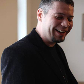

[Goran S. Milovanović](http://www.exactness.net), Phd

Owner, [DataKolektiv](https://www.linkedin.com/company/18515547); Data Scientist for [Wikidata](https://www.wikidata.org) at [WMDE](https://wikimedia.de/); Data Science Mentor at [Springboard](https://www.springboard.com/workshops/data-science)

### A. Installing R and RStudio

**Windows:**

1. Download the binary setup file for R from the following link: https://cran.r-project.org/bin/windows/base/
2. Open the downloaded file and install R by following installation instructions.
3. Download the appropriate binary setup (see section: Installers for Supported Platforms) file for RStudio from the 4. following link: https://www.rstudio.com/products/rstudio/download/
4. Open the downloaded file and install RStudio by following installation instructions.
5. Find RStudio shortcut in Start Menu and open RStudio by clicking on it.

**Apple OS X:**

1. Check OS X version: Choose “About This Mac” option from the Apple menu; the version number appears below the name.
2. Download the appropriate binary setup file for R from the following link: https://cran.r-project.org/bin/macosx/
3. Open the downloaded file and install R by following installation instructions.
4. Download the appropriate binary setup (see section: Installers for Supported Platforms) file for RStudio from the following link: https://www.rstudio.com/products/rstudio/download/
5. Open the downloaded file and install RStudio by dragging the icon to Applications folder.
6. Find RStudio icon in Applications folder and open RStudio by clicking on it.

**Linux Ubuntu >> 16.04 Xenial Xerus**

You know what to do.

4. Note: *The procedure follows the similar lines for previous versions of Ubuntu*

### B. R Playground

Ok. Now when we have our computing toy installed and ready, let’s see what it is about.

```r
# - create a variable
a <- 5
print(a)
```

```
[1] 5
```

```r
# - in Console:
a
```

```
[1] 5
```

```r
# - try this out:
ls()
```

[output not shown]

```r
# - clear workspace
rm(list = ls())
ls()
```

```
character(0)
```

```r
# - remove only one object
a <- 17
a
```

```
[1] 17
```

```r
rm(a)
# - print(a)
```

Basically, R is an calculator:

```r
# - R as a calculator
2 + 2
```

```
[1] 4
```

```r
2/3 - 1 + 5
```

```
[1] 4.666667
```

```r
a <- 1/3
b = 7
a + b
```

```
[1] 7.333333
```

And more or less, that would be all. There’s numbers in R, there’s arithmetic in R, go do Data Science in R… Just kidding of course.

You need to know what’s your working directory:

```r
# what is my working directory?
getwd()
```

```
[1] "/home/goransm/Work/___DataKolektiv/Education/Startit - R Course 2018_19/_code/Introduction-to-R-for-Data-Science/S01 - Introduction to R from RStudio IDE"
```

Setting your working directory:

```r
# - use setwd() to set your working directory
# - setwd('path_to_your_working_directory')
# - setwd(paste0(getwd(), '/_tempData'))
getwd()
```

```
[1] "/home/goransm/Work/___DataKolektiv/Education/Startit - R Course 2018_19/_code/Introduction-to-R-for-Data-Science/S01 - Introduction to R from RStudio IDE"
```

Save as .Rds file:

```r
# - save R object as .rds file
saveRDS(a, "a.rds")
c <- readRDS("a.rds")
print(c)
```

```
[1] 0.3333333
```

Save several objects as .RData:

```r
# save several R objects as .RData file
# - save several R objects as .RData file
save(list = c("a", "b"),
     file = "obj.RData")
# - remove a, b
rm(a, b)
# - load .RDatafile to R
load(file = "obj.RData")
```

Once again, list objects, clean up:

```r
# - list of loaded objects
ls()
```

```
[1] "a" "b" "c"
```

```r
# - remove all objects
rm(list = ls())
```

### C. How to install CRAN packages in R and RStudio

After you have successfully installed both **R** and **RStudio**, you are ready to start programming in R. R has a plenty of built-in functions, but most of the time additional functions are needed. The true power of this programming language lies in the support from approximately 10,000 additional packages that can be installed to widen its functionality.

To install the packages that we are going to use during our course, please follow these steps:

1. Open RStudio from Start Menu (Windows users) or Applications folder (OS X users); Linux users: depends what desktop environment you use.
2. Assume that we want to install the package called: [dplyr](https://cran.r-project.org/web/packages/dplyr/index.html) (it is a well-known R package, indeed)
3. There are two ways to do it (actually, there are more than two ways, but let’s stick with the following two):

###### - **In the RStudio R console (the lower left quadrant of your RStudio workspace), type: install.packages(‘dplyr’)**

###### - **From the Tools menu in RStudio, select Instal Packages, then start typing the package name and select it from the list**

4. Most of the CRAN packages - those found in the standard, official R repository, called CRAN (Comprehensive R Archive Network) can be installed by following the standard procedure (described in Step 3). However, besides this basic package installation procedure, R packages from various sources can be installed in other ways as well. During the workshop we will demonstrate how to install R packages from the [GitHub](https://github.com/) repository (which is not R specific) using the devtools package from R, and how to install packages from the [Bioconductor](https://www.bioconductor.org/) repository.
5. *Note*: sometimes, most often in the R code comments, we use enclose the names of R packages in braces, like: {dplyr}, in order to visually mark the mention of an R package clearly.
6. *Note*: during the installation of some packages, you may notice how R starts installing additional packages - some packages that you have not selected for installation at all! The reason for this is the following: *some R packages rely on R functions developed in some other packages*. When an R package uses functions from another package, the later is called its **dependency**. R will automatically try to install all the dependencies of the package that you have selected for installation, so don’t be surprised if installing one package actually triggers and installation of a dozen of other packages at your system. It’s perfectly normal.

We will use many different R packages during the workshop. Here is a list of the packages that we will be needing; please take some time to practice package installation. To have the following packages pre-installed on the onset of our Workshop would really save us some time: [stringr](https://cran.r-project.org/web/packages/stringr/index.html), [stringi](https://cran.r-project.org/web/packages/stringi/index.html), [dplyr](https://cran.r-project.org/web/packages/dplyr/index.html), [tidyr](https://cran.r-project.org/web/packages/tidyr/index.html), [hflights](https://cran.rstudio.com/web/packages/hflights/index.html), [ggplot2](https://cran.r-project.org/web/packages/ggplot2/index.html), [corrplot](https://cran.r-project.org/web/packages/corrplot/index.html), [ppcor](https://cran.r-project.org/web/packages/ppcor/index.html), [Hmisc](https://cran.r-project.org/web/packages/Hmisc/index.html), [car](https://cran.r-project.org/web/packages/car/index.html), [QuantPsyc](https://cran.r-project.org/web/packages/QuantPsyc/index.html), [broom](https://cran.r-project.org/web/packages/broom/index.html), [lattice](https://cran.r-project.org/web/packages/lattice/index.html).

**REMINDER**: to install a package from the RStudio IDE, type in the console e.g.:

install.packages(“dplyr”)

```r
# installing packages:
# install.packages("dplyr") # replace "dplyr" with other package name
installed.packages() # list of installed packages
```

### D. The Shape of Things to Come

Data types:

```r
### --- The shape of things to come:
numbers <- c(1, 2, 3, 4, 5)
nums <- 1:5
words <- c("data", "science", "r")
boolean <- c(TRUE, FALSE)
data("mtcars")
head(mtcars, 5)
```

|  | mpg | cyl | disp | hp | drat | wt | qsec | vs | am | gear | carb |
| --- | --- | --- | --- | --- | --- | --- | --- | --- | --- | --- | --- |
| Mazda RX4 | 21.0 | 6 | 160 | 110 | 3.90 | 2.620 | 16.46 | 0 | 1 | 4 | 4 |
| Mazda RX4 Wag | 21.0 | 6 | 160 | 110 | 3.90 | 2.875 | 17.02 | 0 | 1 | 4 | 4 |
| Datsun 710 | 22.8 | 4 | 108 | 93 | 3.85 | 2.320 | 18.61 | 1 | 1 | 4 | 1 |
| Hornet 4 Drive | 21.4 | 6 | 258 | 110 | 3.08 | 3.215 | 19.44 | 1 | 0 | 3 | 1 |
| Hornet Sportabout | 18.7 | 8 | 360 | 175 | 3.15 | 3.440 | 17.02 | 0 | 0 | 3 | 2 |

Functions:

```r
# - define a function in R:
factorial <- function(x) {
  if (x == 0 | x == 1) {
    return(1)
  }
  else {
    return(x * factorial(x - 1))
  }
}
```

Function call:

```r
# - calls to factorial():
factorial(5)
```

```
[1] 120
```

```r
factorial(10)
```

```
[1] 3628800
```

```r
factorial(100)
```

```
[1] 9.332622e+157
```

```r
# - a vector of type numeric obtained from a sequence:
xVec <- seq(0, 30, 1)
xVec
```

```
 [1]  0  1  2  3  4  5  6  7  8  9 10 11 12 13 14 15 16 17 18 19 20 21 22 23 24 25 26 27 28 29 30
```

Introducing the apply family:

```r
# - applying the non-vectorized factorial() function to a vector x:
xFactorials <- sapply(xVec, factorial)
xFactorials
```

```
 [1] 1.000000e+00 1.000000e+00 2.000000e+00 6.000000e+00 2.400000e+01 1.200000e+02 7.200000e+02 5.040000e+03
 [9] 4.032000e+04 3.628800e+05 3.628800e+06 3.991680e+07 4.790016e+08 6.227021e+09 8.717829e+10 1.307674e+12
[17] 2.092279e+13 3.556874e+14 6.402374e+15 1.216451e+17 2.432902e+18 5.109094e+19 1.124001e+21 2.585202e+22
[25] 6.204484e+23 1.551121e+25 4.032915e+26 1.088887e+28 3.048883e+29 8.841762e+30 2.652529e+32
```

Sapply w. function definition:

```r
# - applying some other non-vectorized function to a vector:
xSomething <- sapply(xVec, function(x) {
  x <- x + 100
})
xSomething
```

```
 [1] 100 101 102 103 104 105 106 107 108 109 110 111 112 113 114 115 116 117 118 119 120 121 122 123 124 125 126 127
[29] 128 129 130
```

Visualization:

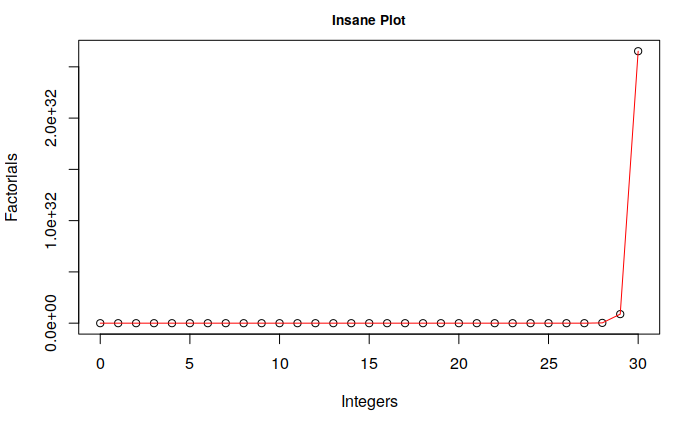

```r
# - a {base} R plot
plot(xVec, xFactorials,
     xlab = "Integers",
     ylab = "Factorials",
     main = "Insane Plot",
     cex.main = .85)
lines(xVec, xFactorials, col = "red")
```

R is a vector programming language. All programming languages dream of becoming vector languages one day. For example, to do vector programming in Python, you first need a package called NumPy to turn it into MATLAB, then a package named Pandas to turn it into R :) N.B. We love Python too and have the highest of respect only for the Python community in Data Science. But R is a “natural” vector programming language:

```r
# - create 100 random deviates from the Uniform on [0,1]
xUnif <- runif(100, 0, 1)
xNorm <- rnorm(100, 5, .75)
# - Hint: ?runif, ?rnorm == asking for help --> documentation
```

```r
# - ask for *each element in x* whether it is >= .5 or not:
xUnif >= .5
```

```
  [1]  TRUE FALSE  TRUE FALSE FALSE FALSE FALSE FALSE  TRUE  TRUE FALSE  TRUE FALSE FALSE FALSE  TRUE FALSE FALSE
 [19]  TRUE FALSE  TRUE FALSE  TRUE FALSE FALSE FALSE  TRUE  TRUE FALSE  TRUE  TRUE FALSE  TRUE FALSE FALSE  TRUE
 [37] FALSE  TRUE FALSE FALSE FALSE FALSE FALSE  TRUE  TRUE  TRUE  TRUE FALSE FALSE  TRUE  TRUE  TRUE FALSE FALSE
 [55]  TRUE  TRUE FALSE FALSE FALSE  TRUE  TRUE  TRUE  TRUE FALSE FALSE FALSE FALSE  TRUE FALSE FALSE  TRUE  TRUE
 [73] FALSE FALSE FALSE  TRUE FALSE  TRUE FALSE FALSE  TRUE  TRUE FALSE FALSE  TRUE  TRUE  TRUE  TRUE  TRUE  TRUE
 [91]  TRUE  TRUE  TRUE FALSE FALSE  TRUE FALSE FALSE  TRUE FALSE
```

```r
# - Where's the function? Isn't >= an operator?
```

R is a functional programming language too. Thus:

```r
logical1 <- '>='(xUnif, .5)
logical1
```

```
  [1]  TRUE FALSE  TRUE FALSE FALSE FALSE FALSE FALSE  TRUE  TRUE FALSE  TRUE FALSE FALSE FALSE  TRUE FALSE FALSE
 [19]  TRUE FALSE  TRUE FALSE  TRUE FALSE FALSE FALSE  TRUE  TRUE FALSE  TRUE  TRUE FALSE  TRUE FALSE FALSE  TRUE
 [37] FALSE  TRUE FALSE FALSE FALSE FALSE FALSE  TRUE  TRUE  TRUE  TRUE FALSE FALSE  TRUE  TRUE  TRUE FALSE FALSE
 [55]  TRUE  TRUE FALSE FALSE FALSE  TRUE  TRUE  TRUE  TRUE FALSE FALSE FALSE FALSE  TRUE FALSE FALSE  TRUE  TRUE
 [73] FALSE FALSE FALSE  TRUE FALSE  TRUE FALSE FALSE  TRUE  TRUE FALSE FALSE  TRUE  TRUE  TRUE  TRUE  TRUE  TRUE
 [91]  TRUE  TRUE  TRUE FALSE FALSE  TRUE FALSE FALSE  TRUE FALSE
```

```r
logical2 <- xUnif >= .5
# - Now: which corresponding elements in logical1
# - and logical 2 are different?
which(logical1 != logical2) # - none: integer(0)
```

```
integer(0)
```

Back to vectorized functions in R; similarly, we have:

```r
xSeq <- seq(2, 100, 2)
x2 <- sqrt(xSeq)
x2
```

```
 [1]  1.414214  2.000000  2.449490  2.828427  3.162278  3.464102  3.741657  4.000000  4.242641  4.472136  4.690416
[12]  4.898979  5.099020  5.291503  5.477226  5.656854  5.830952  6.000000  6.164414  6.324555  6.480741  6.633250
[23]  6.782330  6.928203  7.071068  7.211103  7.348469  7.483315  7.615773  7.745967  7.874008  8.000000  8.124038
[34]  8.246211  8.366600  8.485281  8.602325  8.717798  8.831761  8.944272  9.055385  9.165151  9.273618  9.380832
[45]  9.486833  9.591663  9.695360  9.797959  9.899495 10.000000
```

### F. Stretching its legs w. a simple PCA example

Ok. Let strech its legs now:

```r
### --- PCA example
library(psych)
library(FactoMineR)
data(bfi)
head(bfi)
```

|  | A1 | A2 | A3 | A4 | A5 | C1 | C2 | C3 | C4 | C5 | E1 | E2 | E3 | E4 | E5 | N1 | N2 | N3 | N4 | N5 | O1 | O2 | O3 | O4 | O5 | gender | education | age |
| --- | --- | --- | --- | --- | --- | --- | --- | --- | --- | --- | --- | --- | --- | --- | --- | --- | --- | --- | --- | --- | --- | --- | --- | --- | --- | --- | --- | --- |
| 61617 | 2 | 4 | 3 | 4 | 4 | 2 | 3 | 3 | 4 | 4 | 3 | 3 | 3 | 4 | 4 | 3 | 4 | 2 | 2 | 3 | 3 | 6 | 3 | 4 | 3 | 1 | NA | 16 |
| 61618 | 2 | 4 | 5 | 2 | 5 | 5 | 4 | 4 | 3 | 4 | 1 | 1 | 6 | 4 | 3 | 3 | 3 | 3 | 5 | 5 | 4 | 2 | 4 | 3 | 3 | 2 | NA | 18 |
| 61620 | 5 | 4 | 5 | 4 | 4 | 4 | 5 | 4 | 2 | 5 | 2 | 4 | 4 | 4 | 5 | 4 | 5 | 4 | 2 | 3 | 4 | 2 | 5 | 5 | 2 | 2 | NA | 17 |
| 61621 | 4 | 4 | 6 | 5 | 5 | 4 | 4 | 3 | 5 | 5 | 5 | 3 | 4 | 4 | 4 | 2 | 5 | 2 | 4 | 1 | 3 | 3 | 4 | 3 | 5 | 2 | NA | 17 |
| 61622 | 2 | 3 | 3 | 4 | 5 | 4 | 4 | 5 | 3 | 2 | 2 | 2 | 5 | 4 | 5 | 2 | 3 | 4 | 4 | 3 | 3 | 3 | 4 | 3 | 3 | 1 | NA | 17 |
| 61623 | 6 | 6 | 5 | 6 | 5 | 6 | 6 | 6 | 1 | 3 | 2 | 1 | 6 | 5 | 6 | 3 | 5 | 2 | 2 | 3 | 4 | 3 | 5 | 6 | 1 | 2 | 3 | 21 |

```r
dim(bfi)
```

```
[1] 2800   28
```

```r
dataSet <- bfi[, 1:25]
dim(dataSet)
```

```
[1] 2800   25
```

```r
# - replace NA w. respective column means
for (i in 1:ncol(dataSet)) {
  dataSet[is.na(dataSet[,i]), i] <- mean(dataSet[,i], na.rm = TRUE)
}
colnames(dataSet)
```

```
 [1] "A1" "A2" "A3" "A4" "A5" "C1" "C2" "C3" "C4" "C5" "E1" "E2" "E3" "E4" "E5" "N1" "N2" "N3" "N4" "N5" "O1" "O2"
[23] "O3" "O4" "O5"
```

The correlation matrix visualized w. {corrplot}:

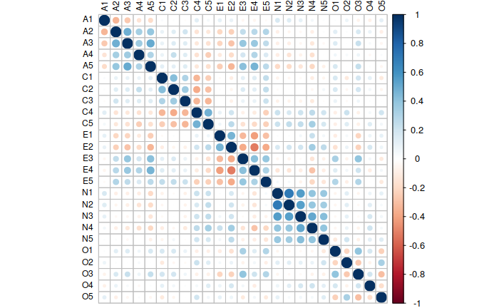

```r
# - plot correlation matrix
library(corrplot)
corrplot(cor(dataSet),
         tl.col = 'black',
         tl.cex = .75)
```

Perform PCA w. PCA() from {factoMineR}; extract eigenvalues:

```r
pcaSolution <- PCA(dataSet,
                   ncp = 5,
                   scale.unit = F,
                   graph = FALSE)
# - Eigenvalues:
eigenvalues <- pcaSolution$eig[, 1]
names(eigenvalues) <- paste("Component: ", seq(1,length(eigenvalues)), sep = "")
eigenvalues
```

```
 Component: 1  Component: 2  Component: 3  Component: 4  Component: 5  Component: 6  Component: 7  Component: 8
   10.4596664     5.9020441     4.0346284     3.4901769     2.9966538     2.1618532     1.8049601     1.7489700
 Component: 9 Component: 10 Component: 11 Component: 12 Component: 13 Component: 14 Component: 15 Component: 16
    1.5107032     1.4327699     1.3418385     1.2159876     1.1802613     1.1462727     1.0987537     0.9961576
Component: 17 Component: 18 Component: 19 Component: 20 Component: 21 Component: 22 Component: 23 Component: 24
    0.9884245     0.9301427     0.8960468     0.8433877     0.8048371     0.7651166     0.7414868     0.6912400
Component: 25
    0.6412184
```

Screeplot w. {ggplot2}

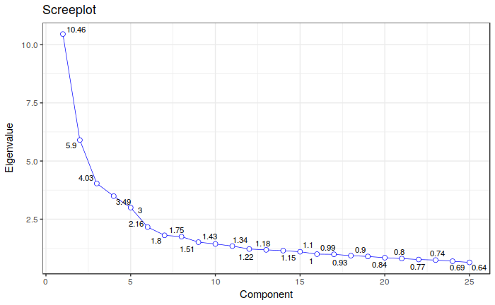

```r
# - Screeplot:
screePlot <- data.frame(Component = rownames(pcaSolution$eig),
                        Eigenvalue = eigenvalues,
                        stringsAsFactors = F)
library(ggplot2)
library(ggrepel)
ggplot(screePlot,
       aes(x = seq(1, length(eigenvalues), 1),
           y = Eigenvalue,
           label = round(Eigenvalue, 2)
           )
       ) +
  geom_path(color = "blue", size = .25) +
  geom_point(color = "blue",size = 2) +
  geom_point(color = "white", size = 1.5) +
  geom_text_repel(size = 3) +
  xlab("Component") +
  ggtitle("Screeplot") +
  theme_bw()
```

Plot loadings on PC1 and PC2

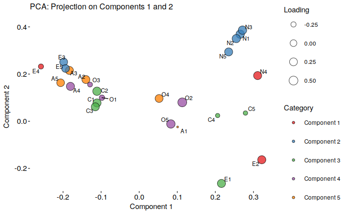

```r
coordinates <- pcaSolution$var$coord
# - compute loadings (dividing coordinates by sqrt(coord_eigenvalue))
for (i in 1:5) {
  coordinates[, i] <- coordinates[, i]/sqrt(eigenvalues[i])
}
colnames(coordinates) <- paste("Component",
                               seq(1, dim(coordinates)[2],1 ), sep = "")
category <- paste("Component ",
                  unname(
                    apply(coordinates, 1, function(x) {
                      which(abs(x) == max(abs(x)))
                      })
                    ),
                  sep = "")
loading <- unname(
  apply(
    coordinates, 1, function(x) {
      x[which(abs(x) == max(abs(x)))]
      })
  )
# - prepare data.frame for {ggplot2}
plotTable <- as.data.frame(coordinates)
plotTable$Category <- category
plotTable$Loading <- loading
plotTable$Label <- rownames(plotTable)
# - plot factor loadings w. {ggplot2}:
# - PCA Projection on Components 1 and 2
ggplot(plotTable,aes(x = Component1,
                     y = Component2,
                     size = Loading,
                     fill = Category,
                     label = Label)) +
  geom_point(color = "black", shape = 21, alpha = 0.75) +
  geom_text_repel(size = 3) +
  theme_bw() +
  scale_size(range = c(1,6)) +
  scale_fill_brewer(palette = "Set1") +
  theme(legend.position = "right") +
  theme(legend.key = element_rect(colour = NA)) +
  theme(legend.key.size = unit(1, "cm")) +
  theme(legend.background = element_rect(colour = "white", fill = "white")) +
  theme(panel.border = element_rect(linetype = "solid", colour = "white", fill = "NA")) +
  theme(panel.background = element_rect(fill = "white")) +
  theme(plot.background = element_blank()) +
  theme(axis.text.x = element_text(size = 11,colour = "black")) +
  theme(axis.text.y = element_text(size = 11,colour = "black")) +
  theme(panel.grid.minor = element_blank()) +
  theme(panel.grid.major = element_blank()) +
  theme(plot.title = element_text(size = 12)) +
  xlab("Component 1") + ylab("Component 2") +
  ggtitle("PCA: Projection on Components 1 and 2\n")
```

[figure not shown]

```r
# plot loadings w. {ggplot2}:
# PCA Projection on Components 1 and 3
ggplot(plotTable,aes(x = Component1,
                     y = Component3,
                     size = Loading,
                     fill = Category,
                     label = Label)) +
  geom_point(color = "black", shape = 21, alpha = 0.75) +
  geom_text_repel(size = 3) +
  theme_bw() +
  scale_size(range = c(1,6)) +
  scale_fill_brewer(palette = "Set1") +
  theme(legend.position = "right") +
  theme(legend.key = element_rect(colour = NA)) +
  theme(legend.key.size = unit(1, "cm")) +
  theme(legend.background = element_rect(colour = "white", fill = "white")) +
  theme(panel.border = element_rect(linetype = "solid", colour = "white", fill = "NA")) +
  theme(panel.background = element_rect(fill = "white")) +
  theme(plot.background = element_blank()) +
  theme(axis.text.x = element_text(size = 11,colour = "black")) +
  theme(axis.text.y = element_text(size = 11,colour = "black")) +
  theme(panel.grid.minor = element_blank()) +
  theme(panel.grid.major = element_blank()) +
  theme(plot.title = element_text(size = 12)) +
  xlab("Component 1") + ylab("Component 2") +
  ggtitle("PCA: Projection on Components 1 and 3\n")
```

### Readings for Session 2:

- Chapters 1 to 3 from [R for Data Science, Garrett Grolemund Hadley Wickham](http://r4ds.had.co.nz/)
- Chapters 1 to 5 from [Norman Matloff’s The Art of R Programming](http://heather.cs.ucdavis.edu/~matloff/132/NSPpart.pdf)